# Assignment2

Süheyla Şeker

17/08/2020

# Package Installation

```r
library(tidyverse)
library(dplyr)
library(ggplot2)
library(lubridate)
library(tidyr)
```

# Reading Data

```r
raw_df <- read.csv2("C:/Users/Suhey/OneDrive/Masaüstü/IE48A/electricitydata.csv")
```

Observing data and it’s structure.

```r
raw_df %>% glimpse()
```

```
## Rows: 744
## Columns: 7
## $ Tarih                               <chr> "01.07.2020", "01.07.2020", "01...
## $ Saat                                <chr> "00:00", "01:00", "02:00", "03:...
## $ PTF                                 <dbl> 323.85, 326.95, 324.31, 322.11,...
## $ SMF                                 <dbl> 211.00, 201.00, 211.00, 211.00,...
## $ Pozitif.Dengesizlik.Fiyatı..TL.MWh. <dbl> 204.67, 194.97, 204.67, 204.67,...
## $ Negatif.Dengesizlik.Fiyatı..TL.MWh. <dbl> 333.57, 336.76, 334.04, 331.77,...
## $ SMF.Yön                             <chr> "?Enerji Fazlası", "?Enerji Faz...
```

```r
head(raw_df)
```

```
##        Tarih  Saat    PTF SMF Pozitif.Dengesizlik.Fiyatı..TL.MWh.
## 1 01.07.2020 00:00 323.85 211                              204.67
## 2 01.07.2020 01:00 326.95 201                              194.97
## 3 01.07.2020 02:00 324.31 211                              204.67
## 4 01.07.2020 03:00 322.11 211                              204.67
## 5 01.07.2020 04:00 320.00 201                              194.97
## 6 01.07.2020 05:00 286.21 181                              175.57
##   Negatif.Dengesizlik.Fiyatı..TL.MWh.         SMF.Yön
## 1                              333.57 ?Enerji Fazlası
## 2                              336.76 ?Enerji Fazlası
## 3                              334.04 ?Enerji Fazlası
## 4                              331.77 ?Enerji Fazlası
## 5                              329.60 ?Enerji Fazlası
## 6                              294.80 ?Enerji Fazlası
```

Deleting “?” character from the SMF.Yön column’s data.

```r
raw_df=raw_df %>% mutate(SMF.Yön= as.character(sub(".", "", SMF.Yön)))
```

Converting date’s information to POSIXct format in order to manipulate data easily.

```r
raw_df<-raw_df %>% mutate(Tarih=as.POSIXct(factor(Tarih), format="%d.%m.%y")) %>%
transmute(Tarih, Saat,PTF,SMF,SMF.Yön, Tarih = as_date(Tarih), Day= weekdays(Tarih))
```

Changing column names.

```r
raw_df<-raw_df %>%rename(Date=Tarih,Hour=Saat)
```

Creating `data1` and `dataDay` dataframes in order to analyze total PTF and SMF prices and percentage change in those prices for each week days.

```r
data1<-raw_df %>% group_by(Day) %>%summarise(TotalPTF = sum(PTF),TotalSMF= sum(SMF))
dataDay<-data1 %>% group_by(Day)%>%summarise(Difference=TotalSMF-TotalPTF,PercentageChange=Difference/TotalPTF)
```

# Visualization of Percentage Change in Total PTF and SMF Prices for Each Week Days

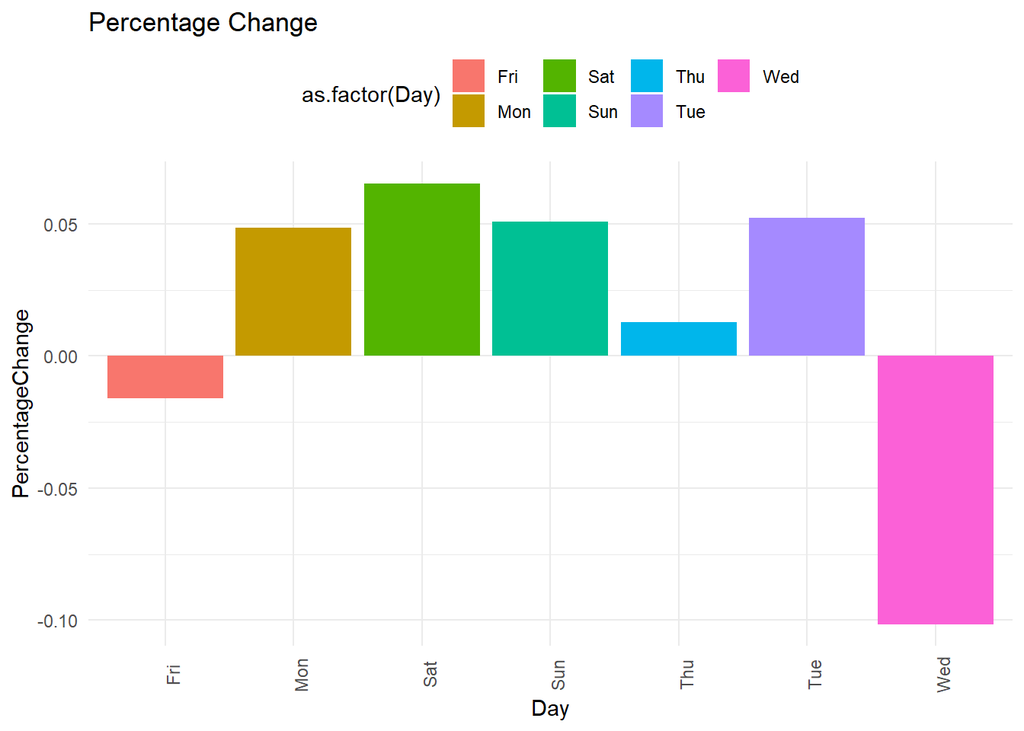

```r
ggplot(dataDay,aes(x=Day,y=PercentageChange,fill=as.factor(Day))) + geom_bar(stat="identity",position="dodge") +
  theme_minimal() +
  labs(x="Day",y="PercentageChange",title="Percentage Change") +
  theme(axis.text.x = element_text(angle=90),legend.position = "top")
```

# Understanding The Relation Between Certain Days of Week and SMF Prices

Filtering SMF price data and taking average of SMF prices for each week day in July, in order to analyze the relation between certain days of week and SMF prices.

```r
data2<-raw_df%>% filter(Day== "Mon")
data2.1<- data2%>%group_by(Hour)%>% summarise(Day,AvgMonSMF=mean(SMF))
data2.1<-unique(data2.1)
data3<-raw_df%>% filter(Day== "Tue")
data3.1<- data3%>%group_by(Hour)%>% summarise(Day,AvgTueSMF=mean(SMF))
data3.1<-unique(data3.1)
data4<-raw_df%>% filter(Day== "Wed")
data4.1<- data4%>%group_by(Hour)%>% summarise(Day,AvgWedSMF=mean(SMF))
data4.1<-unique(data4.1)
data5<-raw_df%>% filter(Day== "Thu")
data5.1<- data5%>%group_by(Hour)%>% summarise(Day,AvgThuSMF=mean(SMF))
data5.1<-unique(data5.1)
data6<-raw_df%>% filter(Day== "Fri")
data6.1<- data6%>%group_by(Hour)%>% summarise(Day,AvgFriSMF=mean(SMF))
data6.1<-unique(data6.1)
data7<-raw_df%>% filter(Day== "Sat")
data7.1<- data7%>%group_by(Hour)%>% summarise(Day,AvgSatSMF=mean(SMF))
data7.1<-unique(data7.1)
data8<-raw_df%>% filter(Day== "Sun")
data8.1<- data8%>%group_by(Hour)%>% summarise(Day,AvgSunSMF=mean(SMF))
data8.1<-unique(data8.1)
```

# Visualization of Relation Between Certain Days of Week and Average SMF Prices

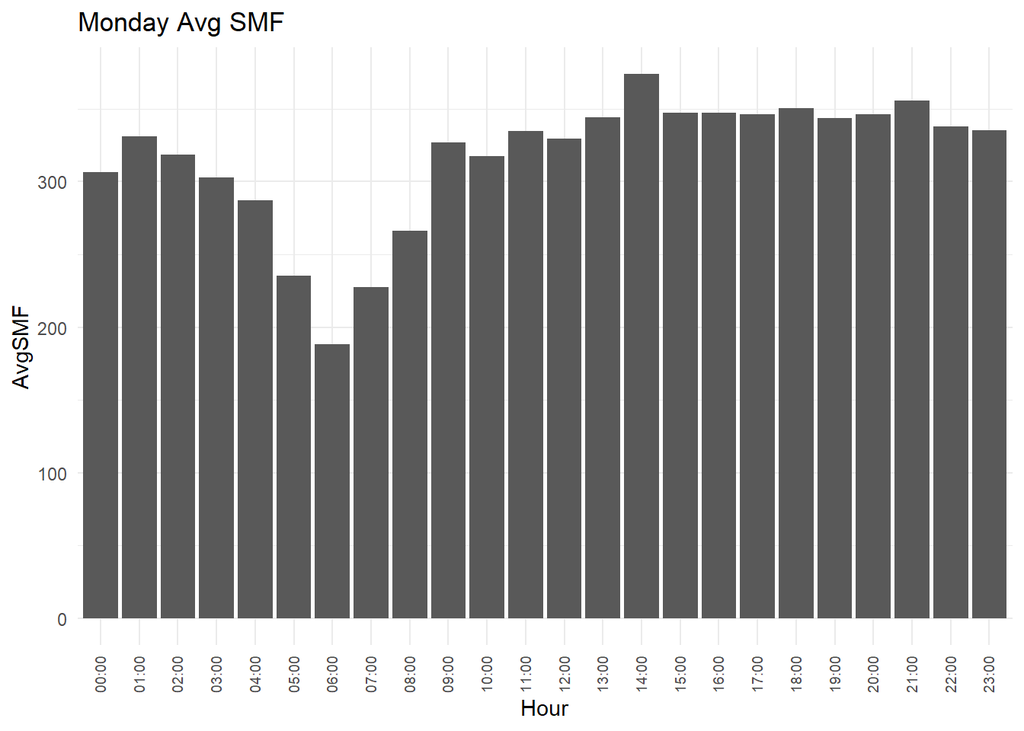

```r
ggplot(data2.1,aes(x=Hour,y=AvgMonSMF)) + geom_bar(stat="identity",position="dodge") +
  theme_minimal() +
  labs(x="Hour",y="AvgSMF",title="Monday Avg SMF") +
  theme(axis.text.x = element_text(angle=90,size=7,vjust=0.4),legend.position = "top")
```

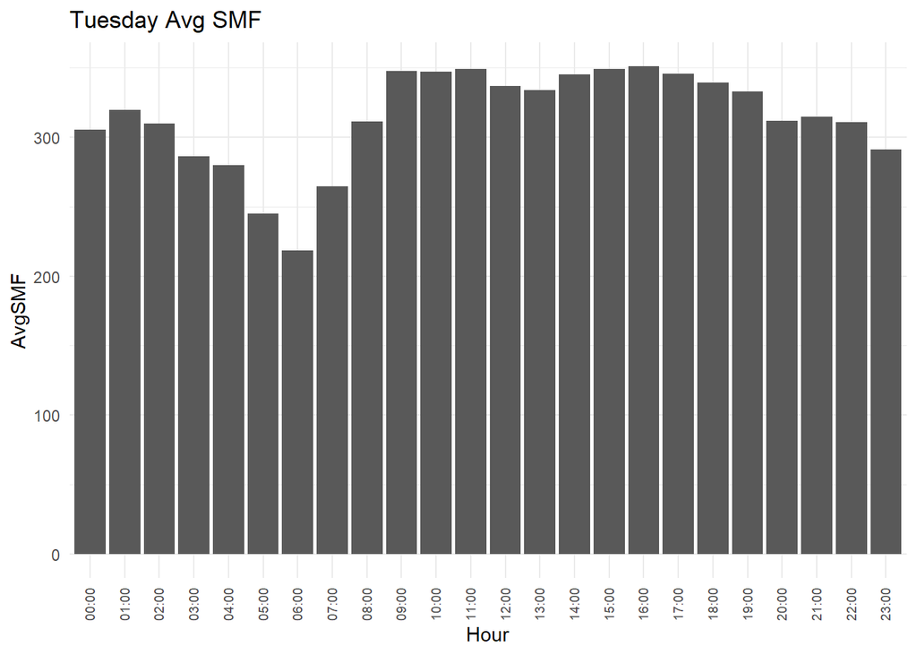

```r
ggplot(data3.1,aes(x=Hour,y=AvgTueSMF)) + geom_bar(stat="identity",position="dodge") +
  theme_minimal() +
  labs(x="Hour",y="AvgSMF",title="Tuesday Avg SMF") +
  theme(axis.text.x = element_text(angle=90,size=7,vjust=0.4),legend.position = "top")
```

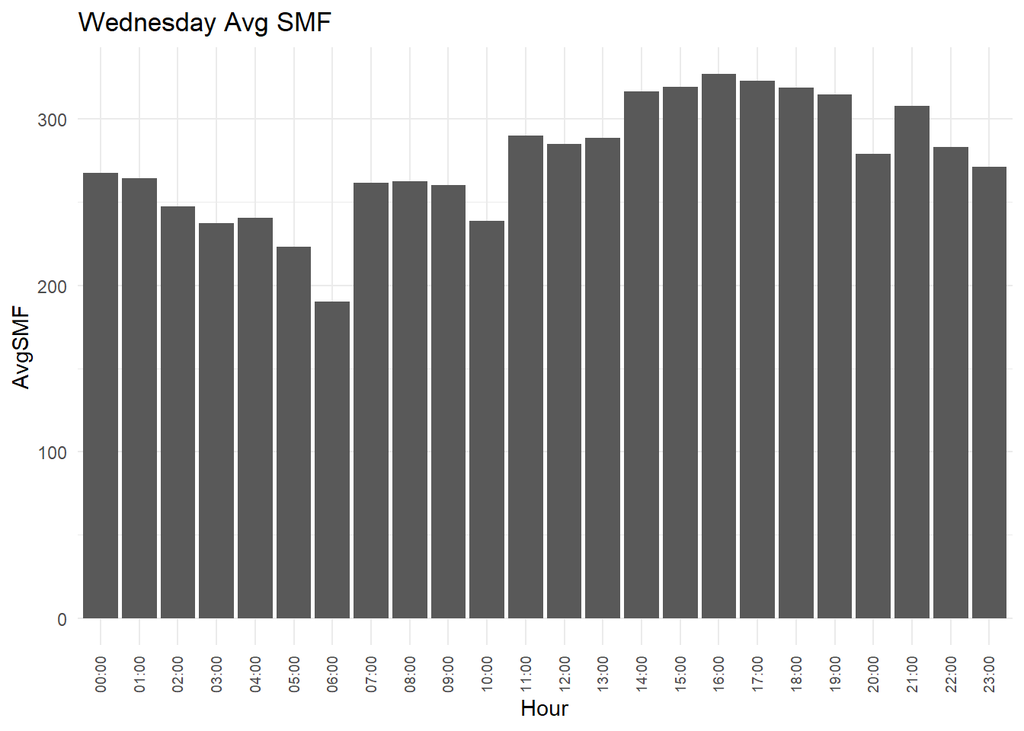

```r
ggplot(data4.1,aes(x=Hour,y=AvgWedSMF)) + geom_bar(stat="identity",position="dodge") +
  theme_minimal() +
  labs(x="Hour",y="AvgSMF",title="Wednesday Avg SMF") +
  theme(axis.text.x = element_text(angle=90,size=7,vjust=0.4),legend.position = "top")
```

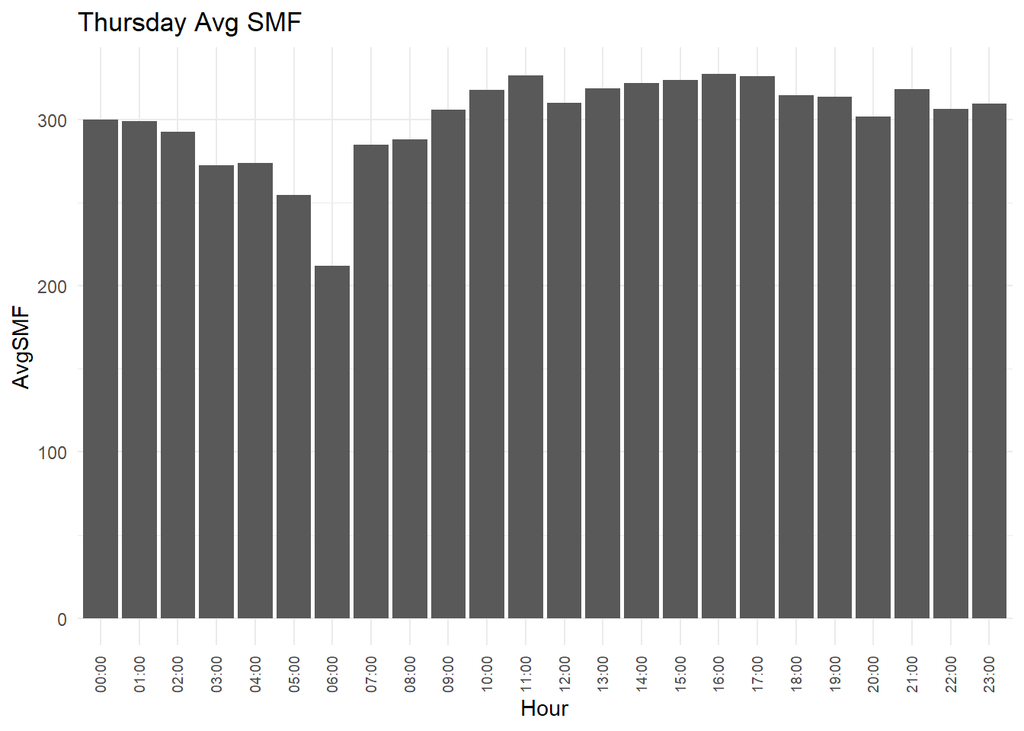

```r
ggplot(data5.1,aes(x=Hour,y=AvgThuSMF)) + geom_bar(stat="identity",position="dodge") +
  theme_minimal() +
  labs(x="Hour",y="AvgSMF",title="Thursday Avg SMF") +
  theme(axis.text.x = element_text(angle=90,size=7,vjust=0.4),legend.position = "top")
```

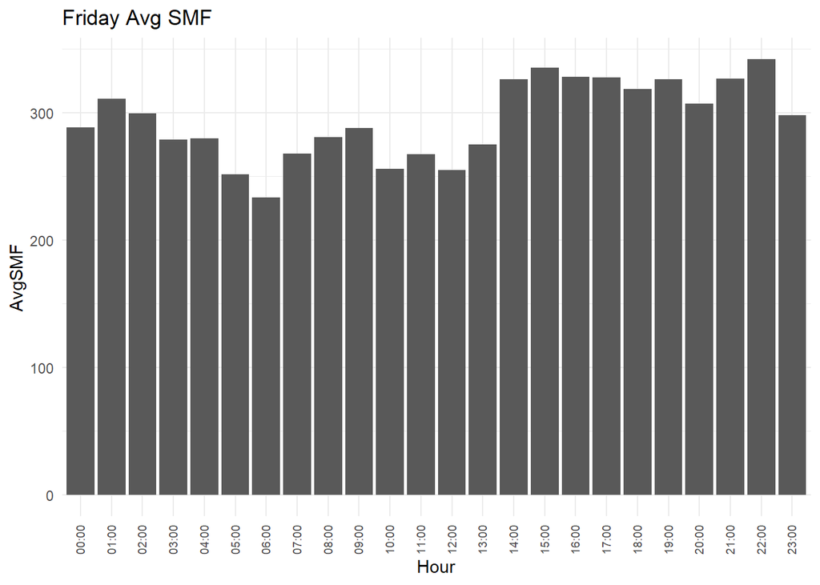

```r
ggplot(data6.1,aes(x=Hour,y=AvgFriSMF)) + geom_bar(stat="identity",position="dodge") +
  theme_minimal() +
  labs(x="Hour",y="AvgSMF",title="Friday Avg SMF") +
  theme(axis.text.x = element_text(angle=90,size=7,vjust=0.4),legend.position = "top")
```

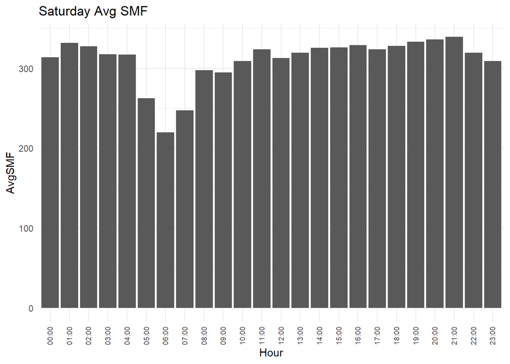

```r
ggplot(data7.1,aes(x=Hour,y=AvgSatSMF)) + geom_bar(stat="identity",position="dodge") +
  theme_minimal() +
  labs(x="Hour",y="AvgSMF",title="Saturday Avg SMF") +
  theme(axis.text.x = element_text(angle=90,size=7,vjust=0.4),legend.position = "top")
```

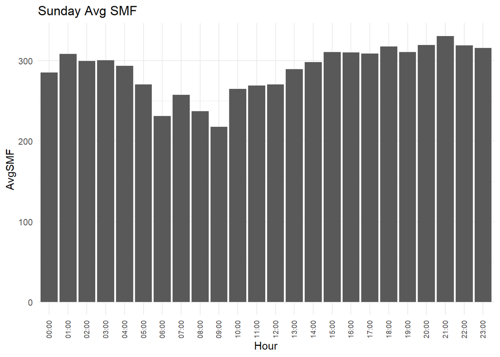

```r
ggplot(data8.1,aes(x=Hour,y=AvgSunSMF)) + geom_bar(stat="identity",position="dodge") +
  theme_minimal() +
  labs(x="Hour",y="AvgSMF",title="Sunday Avg SMF") +
  theme(axis.text.x = element_text(angle=90,size=7,vjust=0.4),legend.position = "top")
```

It can be seen that average SMF prices decreases early in the morning and increases afternoon.

Then I wanted to analyze whether religious activity at Fridays affect SMF prices or not. First I analyzed SMF prices on all Fridays in July.

```r
plot_df1<- raw_df%>% filter(Day== "Fri")
```

Visualization of SMF prices at Fridays

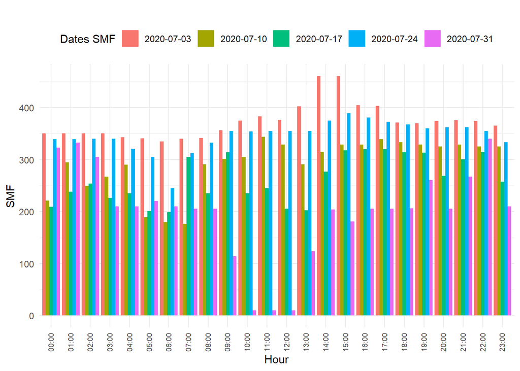

```r
ggplot(plot_df1,aes(x=Hour,y=SMF,fill=as.factor(Date))) + geom_bar(stat="identity",position="dodge") +
  theme_minimal() +
  labs(x="Hour",y="SMF",title="",fill="Dates SMF") +
  theme(axis.text.x = element_text(angle=90,size=7,vjust=0.4),legend.position = "top")
```

Then, I wanted to analyze each Friday specifically by analyzing SMF prices and hours.By doing this I also focused on praying times which is between 13:00- 14:00.

```r
plot_df2<- raw_df%>% filter(Date== "2020-07-03")
plot_df3<- raw_df%>% filter(Date=="2020-07-10")
plot_df4<- raw_df%>% filter(Date=="2020-07-17")
plot_df5<- raw_df%>% filter(Date=="2020-07-24")
plot_df6<- raw_df%>% filter(Date=="2020-07-31")
```

# Visualization of relation between each Friday and hours effect on SMF prices

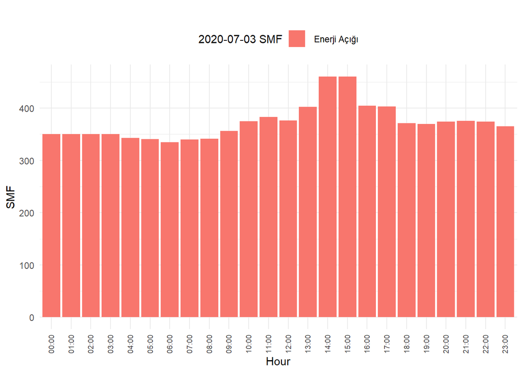

```r
ggplot(plot_df2,aes(x=Hour,y=SMF,fill=as.factor(SMF.Yön))) + geom_bar(stat="identity",position="dodge") +
  theme_minimal() +
  labs(x="Hour",y="SMF",title="",fill="2020-07-03 SMF") +
  theme(axis.text.x = element_text(angle=90,size=7,vjust=0.4),legend.position = "top")
```

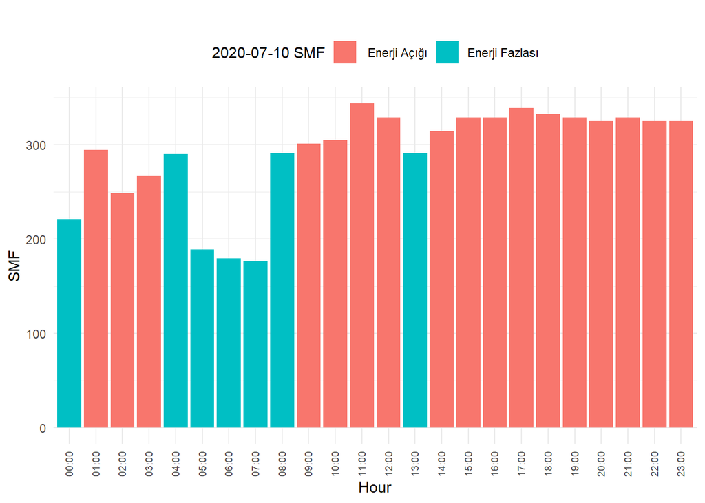

```r
ggplot(plot_df3,aes(x=Hour,y=SMF,fill=as.factor(SMF.Yön))) + geom_bar(stat="identity",position="dodge") +
  theme_minimal() +
  labs(x="Hour",y="SMF",title="",fill="2020-07-10 SMF") +
  theme(axis.text.x = element_text(angle=90,size=7,vjust=0.4),legend.position = "top")
```

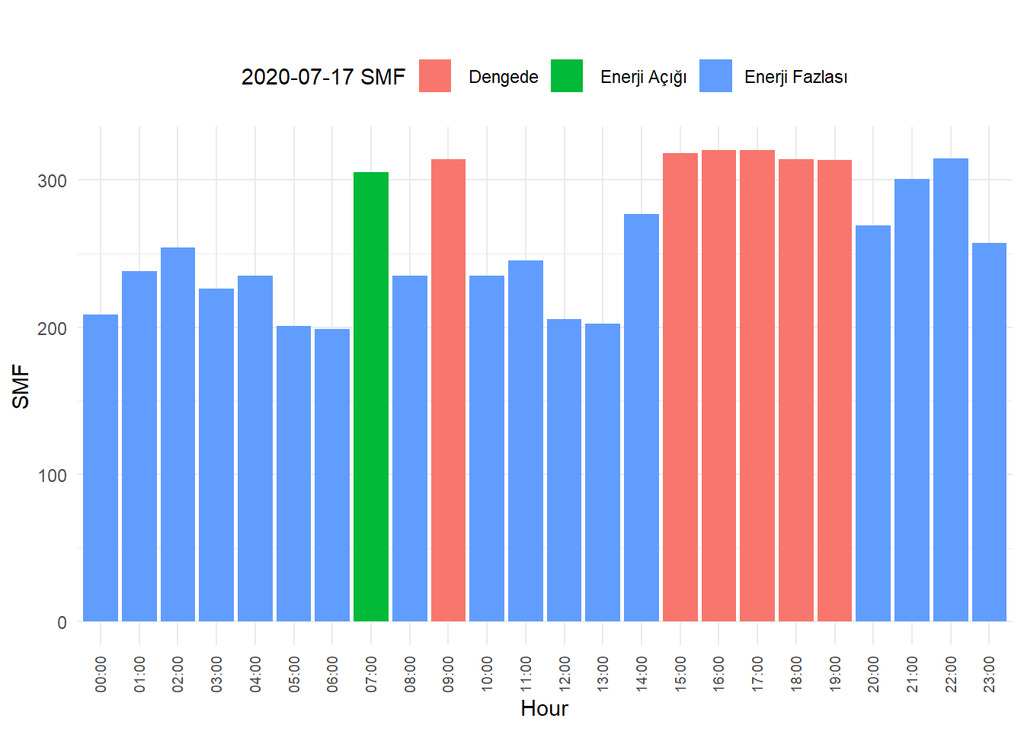

```r
ggplot(plot_df4,aes(x=Hour,y=SMF,fill=as.factor(SMF.Yön))) + geom_bar(stat="identity",position="dodge") +
  theme_minimal() +
  labs(x="Hour",y="SMF",title="",fill="2020-07-17 SMF") +
  theme(axis.text.x = element_text(angle=90,size=7,vjust=0.4),legend.position = "top")
```

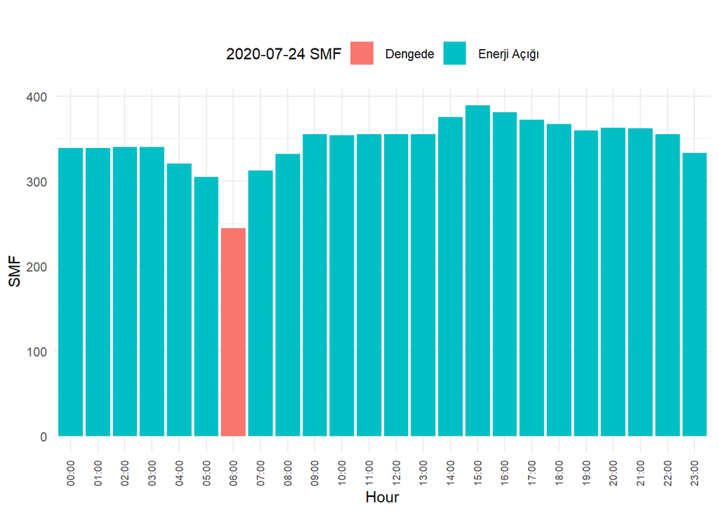

```r
ggplot(plot_df5,aes(x=Hour,y=SMF,fill=as.factor(SMF.Yön))) + geom_bar(stat="identity",position="dodge") +
  theme_minimal() +
  labs(x="Hour",y="SMF",title="",fill="2020-07-24 SMF") +
  theme(axis.text.x = element_text(angle=90,size=7,vjust=0.4),legend.position = "top")
```

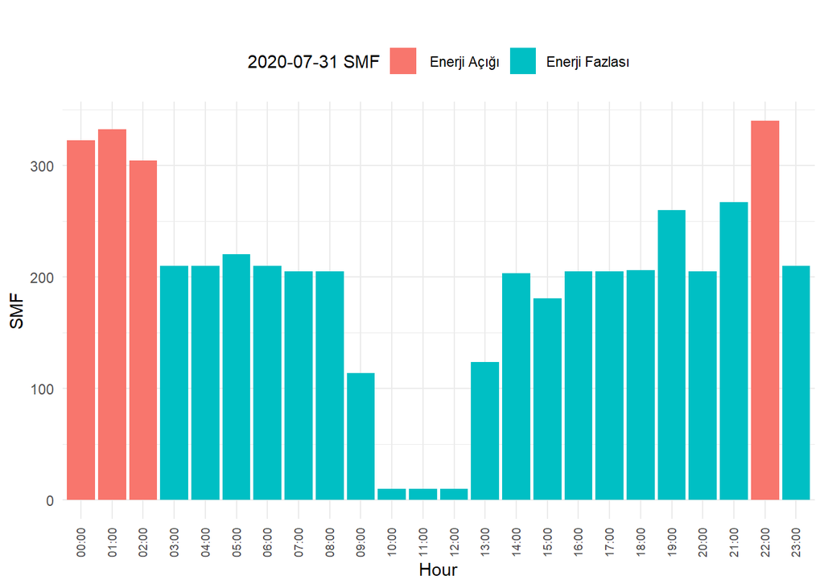

```r
ggplot(plot_df6,aes(x=Hour,y=SMF,fill=as.factor(SMF.Yön))) + geom_bar(stat="identity",position="dodge") +
  theme_minimal() +
  labs(x="Hour",y="SMF",title="",fill="2020-07-31 SMF") +
  theme(axis.text.x = element_text(angle=90,size=7,vjust=0.4),legend.position = "top")
```

#Effect of praying hours on SMF Prices

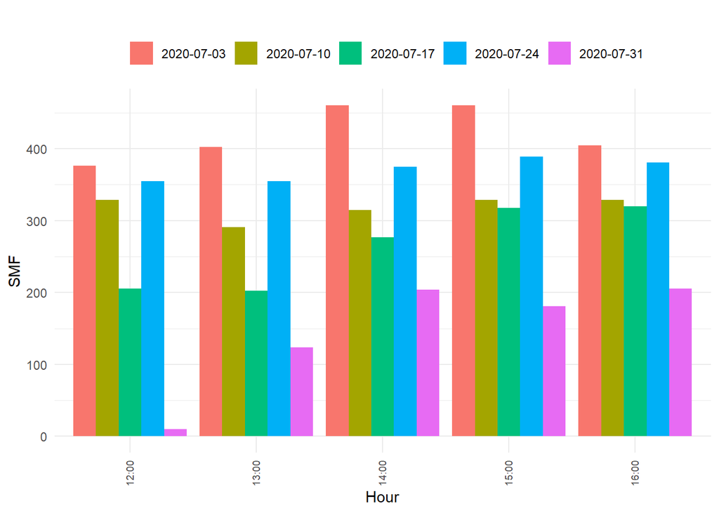

```r
plot_df7<- plot_df1%>% filter(Hour>= "12:00" & Hour<= "16:00")

ggplot(plot_df7,aes(x=Hour,y=SMF,fill=as.factor(Date))) + geom_bar(stat="identity",position="dodge") +
  theme_minimal() +
  labs(x="Hour",y="SMF",title="",fill="") +
  theme(axis.text.x = element_text(angle=90,size=7,vjust=0.4),legend.position = "top")
```

By looking at SMF prices at praying hours, it can be seen that SMF prices might increase between praying hours but other factors must also be examined to be sure.

# Conclusion

- There might be a relation between praying hours on Fridays and SMF prices.
- Electricity demand might increase after working hours since people spend more time in their houses and decrease early in the morning since they sleep.

# References

- Data Set: [EPIAS/EXIST Transparency Platform](https://rapor.epias.com.tr/rapor/xhtml/ptfSmfListeleme.xhtml)
- Lecture Notes: [Berk Orbay IE48A](https://boun-ie48a.github.io/files/dplyr_renewable.html)
- Lecture Notes: [Berk Orbay IE48A](https://boun-ie48a.github.io/files/ggplot2_renewable.html)